### Bibliotecas Utilizadas

```python
import pandas as pd
import matplotlib.pyplot as plt
import seaborn as sns
from sklearn.preprocessing import MultiLabelBinarizer
```

#### Leitura dos Dados

```python
df = pd.read_csv(r"C:\Users\Giovana Santiago Lim\Downloads\desafio_indicium_imdb.csv")
```

```python
df.info()
```

```
<class 'pandas.core.frame.DataFrame'>
RangeIndex: 999 entries, 0 to 998
Data columns (total 16 columns):
 #   Column         Non-Null Count  Dtype
---  ------         --------------  -----
 0   Unnamed: 0     999 non-null    int64
 1   Series_Title   999 non-null    object
 2   Released_Year  999 non-null    object
 3   Certificate    898 non-null    object
 4   Runtime        999 non-null    object
 5   Genre          999 non-null    object
 6   IMDB_Rating    999 non-null    float64
 7   Overview       999 non-null    object
 8   Meta_score     842 non-null    float64
 9   Director       999 non-null    object
 10  Star1          999 non-null    object
 11  Star2          999 non-null    object
 12  Star3          999 non-null    object
 13  Star4          999 non-null    object
 14  No_of_Votes    999 non-null    int64
 15  Gross          830 non-null    object
dtypes: float64(2), int64(2), object(12)
memory usage: 125.0+ KB
```

```python
df.head()
```

|  | Unnamed: 0 | Series_Title | Released_Year | Certificate | Runtime | Genre | IMDB_Rating | Overview | Meta_score | Director | Star1 | Star2 | Star3 | Star4 | No_of_Votes | Gross |
| --- | --- | --- | --- | --- | --- | --- | --- | --- | --- | --- | --- | --- | --- | --- | --- | --- |
| 0 | 1 | The Godfather | 1972 | A | 175 min | Crime, Drama | 9.2 | An organized crime dynasty's aging patriarch t... | 100.0 | Francis Ford Coppola | Marlon Brando | Al Pacino | James Caan | Diane Keaton | 1620367 | 134,966,411 |
| 1 | 2 | The Dark Knight | 2008 | UA | 152 min | Action, Crime, Drama | 9.0 | When the menace known as the Joker wreaks havo... | 84.0 | Christopher Nolan | Christian Bale | Heath Ledger | Aaron Eckhart | Michael Caine | 2303232 | 534,858,444 |
| 2 | 3 | The Godfather: Part II | 1974 | A | 202 min | Crime, Drama | 9.0 | The early life and career of Vito Corleone in ... | 90.0 | Francis Ford Coppola | Al Pacino | Robert De Niro | Robert Duvall | Diane Keaton | 1129952 | 57,300,000 |
| 3 | 4 | 12 Angry Men | 1957 | U | 96 min | Crime, Drama | 9.0 | A jury holdout attempts to prevent a miscarria... | 96.0 | Sidney Lumet | Henry Fonda | Lee J. Cobb | Martin Balsam | John Fiedler | 689845 | 4,360,000 |
| 4 | 5 | The Lord of the Rings: The Return of the King | 2003 | U | 201 min | Action, Adventure, Drama | 8.9 | Gandalf and Aragorn lead the World of Men agai... | 94.0 | Peter Jackson | Elijah Wood | Viggo Mortensen | Ian McKellen | Orlando Bloom | 1642758 | 377,845,905 |

A partir de uma análise inicial do conjunto de dados, utilizando os métodos .info() e .head(), é possível identificar inconsistências que demandam intervenção. 1) Observa-se a presença de uma coluna redundante (Unnamed: 0), que funciona como um índice duplicado. 2) Notou-se uma discrepância entre o tipo de dado e o conteúdo real de colunas como released_year, runtime—que continha a string "min"—e gross—que apresentava valores monetários com vírgulas, impedindo sua classificação como numérica. 3) A inspeção também apontou a ocorrência de dados ausentes (NaN) nas colunas certificate, meta_score e gross. 4) Constatou-se que a coluna genre possuía entradas multivaloradas, onde cada registro podia conter múltiplos gêneros separados por vírgulas, indicando a necessidade de um processo de splitting para uma análise adequada.

#### Tratamento dos Dados

```python
# Exclusão da coluna Unnamed
df.drop('Unnamed: 0', axis=1, inplace=True)
```

```python
#Conversão de Tipos de Dados
df["Released_Year"] = pd.to_numeric(df["Released_Year"], errors="coerce").astype("Int64")

df["Runtime"] = df["Runtime"].apply(lambda x: str(x).replace("min", "").strip())
df["Runtime"] = pd.to_numeric(df["Runtime"], errors="coerce")

df["Gross"] = df["Gross"].apply(lambda x: str(x).replace(",", "").strip())
df["Gross"] = pd.to_numeric(df["Gross"], errors="coerce")
```

```python
#Tratamento de Dados Ausentes
df.dropna(subset=['Gross'], inplace=True)


mediana_meta = df['Meta_score'].median()
df['Meta_score'].fillna(mediana_meta, inplace=True)


moda_certificate = df['Certificate'].mode()[0]
df['Certificate'].fillna(moda_certificate, inplace=True)
```

Para a coluna **Gross**, que representa o faturamento, optou-se pela exclusão das linhas com valores ausentes. A decisão deve-se ao fato de que a imputação de médias ou medianas poderia distorcer significativamente a análise da rentabilidade, uma vez que a distribuição de receita no setor cinematográfico é tipicamente assimétrica. Dessa forma, considerou-se mais seguro trabalhar exclusivamente com dados de receita comprovados.

No caso da coluna **meta_score**, que reflete avaliações críticas, utilizou-se a imputação pela **mediana**. Essa medida é menos sensível a valores extremos e oferece uma representação mais estável para variáveis de avaliação, que tendem a apresentar distribuição mais regular.

Por fim, para a coluna **certificate**, de natureza categórica, aplicou-se a imputação pela **moda**, técnica mais adequada para este tipo de dado, uma vez que consiste simplesmente em preencher os valores faltantes com a categoria mais frequente no conjunto de dados.

```python
#Normalização de Coluna Multivalorada
generos_unicos = df['Genre'].str.split(', ').explode().unique()
print(f"Número de gêneros únicos encontrados: {len(generos_unicos)}")
print(f"Exemplo de gêneros únicos: {generos_unicos}")
```

```
Número de gêneros únicos encontrados: 21
Exemplo de gêneros únicos: ['Crime' 'Drama' 'Action' 'Adventure' 'Biography' 'History' 'Sci-Fi'
 'Romance' 'Western' 'Fantasy' 'Comedy' 'Thriller' 'Animation' 'Family'
 'War' 'Mystery' 'Music' 'Horror' 'Sport' 'Musical' 'Film-Noir']
```

```python
mlb = MultiLabelBinarizer()
generos_transform = mlb.fit_transform(df['Genre'].str.split(', '))
generos_dummies = pd.DataFrame(generos_transform, columns=mlb.classes_, index=df.index)
```

```python
generos_dummies
```

|  | Action | Adventure | Animation | Biography | Comedy | Crime | Drama | Family | Fantasy | Film-Noir | ... | Horror | Music | Musical | Mystery | Romance | Sci-Fi | Sport | Thriller | War | Western |
| --- | --- | --- | --- | --- | --- | --- | --- | --- | --- | --- | --- | --- | --- | --- | --- | --- | --- | --- | --- | --- | --- |
| 0 | 0 | 0 | 0 | 0 | 0 | 1 | 1 | 0 | 0 | 0 | ... | 0 | 0 | 0 | 0 | 0 | 0 | 0 | 0 | 0 | 0 |
| 1 | 1 | 0 | 0 | 0 | 0 | 1 | 1 | 0 | 0 | 0 | ... | 0 | 0 | 0 | 0 | 0 | 0 | 0 | 0 | 0 | 0 |
| 2 | 0 | 0 | 0 | 0 | 0 | 1 | 1 | 0 | 0 | 0 | ... | 0 | 0 | 0 | 0 | 0 | 0 | 0 | 0 | 0 | 0 |
| 3 | 0 | 0 | 0 | 0 | 0 | 1 | 1 | 0 | 0 | 0 | ... | 0 | 0 | 0 | 0 | 0 | 0 | 0 | 0 | 0 | 0 |
| 4 | 1 | 1 | 0 | 0 | 0 | 0 | 1 | 0 | 0 | 0 | ... | 0 | 0 | 0 | 0 | 0 | 0 | 0 | 0 | 0 | 0 |
| ... | ... | ... | ... | ... | ... | ... | ... | ... | ... | ... | ... | ... | ... | ... | ... | ... | ... | ... | ... | ... | ... |
| 989 | 0 | 0 | 0 | 0 | 0 | 0 | 1 | 0 | 0 | 0 | ... | 0 | 0 | 0 | 0 | 0 | 0 | 0 | 0 | 1 | 1 |
| 990 | 0 | 1 | 0 | 0 | 1 | 0 | 0 | 0 | 0 | 0 | ... | 0 | 0 | 0 | 0 | 0 | 0 | 0 | 0 | 1 | 0 |
| 991 | 0 | 1 | 1 | 0 | 0 | 0 | 0 | 1 | 0 | 0 | ... | 0 | 0 | 0 | 0 | 0 | 0 | 0 | 0 | 0 | 0 |
| 993 | 0 | 0 | 0 | 0 | 1 | 0 | 0 | 0 | 0 | 0 | ... | 0 | 1 | 1 | 0 | 0 | 0 | 0 | 0 | 0 | 0 |
| 996 | 0 | 0 | 0 | 0 | 0 | 0 | 1 | 0 | 0 | 0 | ... | 0 | 0 | 0 | 0 | 1 | 0 | 0 | 0 | 1 | 0 |

830 rows × 21 columns

Para analisar a coluna genre, que contém múltiplos gêneros separados por vírgulas em uma única string, foi necessário primeiro transformar essa representação em uma estrutura tabular adequada. O processo iniciou com a identificação de que existiam 21 gêneros únicos no conjunto de dados, como 'Action', 'Drama', 'Sci-Fi', entre outros. Utilizou-se a técnica MultiLabelBinarizer da biblioteca scikit-learn, que é projetada especificamente para este tipo de cenário.

### Análise Exploratória de Dados

#### Distribuição das notas

A pontuação IMDb (Internet Movie Database) é uma média das notas dos usuários do site IMDb refletindo a opinião do público.

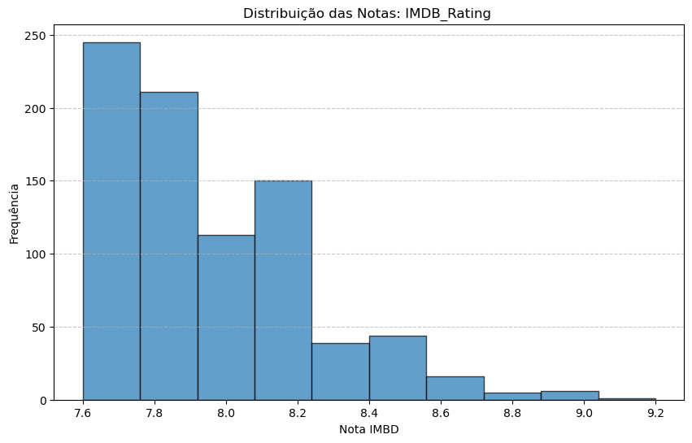

```python
plt.figure(figsize=(10, 6))
plt.hist(df['IMDB_Rating'], bins=10, edgecolor='black', alpha=0.7)
plt.title('Distribuição das Notas: IMDB_Rating ')
plt.xlabel('Nota IMBD')
plt.ylabel('Frequência')
plt.grid(axis='y', linestyle='--', alpha=0.7)
plt.savefig('histograma_idades.png')
```

A distribuição das notas do IMDB mostra que a maioria dos filmes possui uma nota entre 7,6 e 8,2 com o pico entre 7,6 e 7,8. Essa concentração indica que o dataset é composto por filmes considerados bons pelo público e provavelmente filmes populares. Não são filmes medianos, mas também não são filmes considerados obras primas.

Observa-se que a frequencia diminui para notas acima de 8,2 com poucos filmes atingindo uma nota maior que 9,0. Nesse contexto, um filme com nota 8,5 está dentre os melhores filmes do site. Assim, pode-se inferir que para um diretor atingir uma nota maior que 8,2 é um sinal de sucesso.

A pontuação Meta Score é uma avaliação mais crítica e especializada de um filme, calculada através da média ponderada das pontuações e críticas de jornalistas especializados e crítica de cinema.

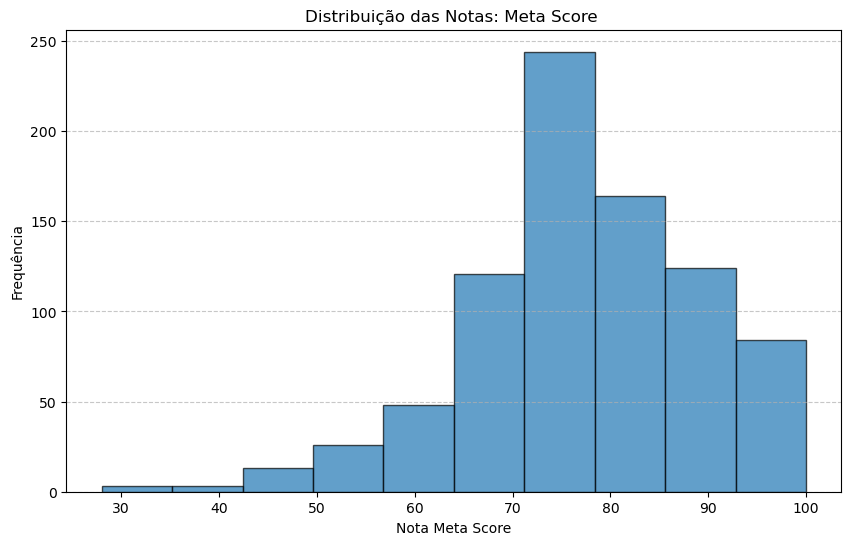

```python
plt.figure(figsize=(10, 6))
plt.hist(df['Meta_score'], bins=10, edgecolor='black', alpha=0.7)
plt.title('Distribuição das Notas: Meta Score ')
plt.xlabel('Nota Meta Score')
plt.ylabel('Frequência')
plt.grid(axis='y', linestyle='--', alpha=0.7)
plt.savefig('histograma_idades.png')
```

A maioria dos filmes tem um meta escore entre 60 e 90, com o maior pico entre 70 e 80, o que sugere que a crítica normalmente é positiva e os filmes são avaliados como bons, visto que para crítica uma nota 60, representa aprovação.

Diferente do público é possivel notar que a opinião especializada possui uma variadade maior de opiniões e qualidade, dado que existem mais notas medianas e excepcionais do que o público em que as avaliações estão concentradas mais no topo.

#### Distribuição do número de votos

[figure not shown]

```python
plt.figure(figsize=(10, 6))
plt.hist(df['No_of_Votes'], bins=10, edgecolor='black', alpha=0.7)
plt.title('Distribuição do número de votos (em milhões) ')
plt.xlabel('Número de votos')
plt.ylabel('Frequência')
plt.grid(axis='y', linestyle='--', alpha=0.7)
plt.savefig('histograma_idades.png')
```

```python
df['No_of_Votes'].sort_values(ascending=False).head(10)
```

```
1     2303232
7     2067042
8     1854740
5     1826188
10    1809221
13    1676426
9     1661481
4     1642758
0     1620367
62    1516346
Name: No_of_Votes, dtype: int64
```

Observa-se que a msioria dos filmes tem um número de votos baixo, concentrado na faixa entre 0 a 250000 votos, o que permite inferir que o universo cinematográfico é desigual com poucos filmes com mais de 1 milhão de votos.

#### Correlação entre as variáveis de avaliação

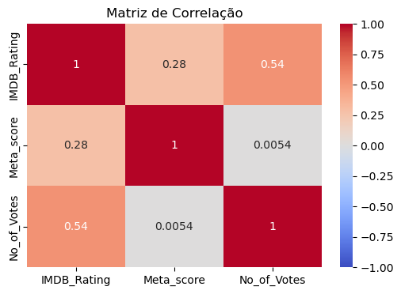

```python
colunas = ['IMDB_Rating', 'Meta_score', 'No_of_Votes']
corrs = df[cols].corr()

plt.figure(figsize=(6,4))
sns.heatmap(correlacoes, annot=True, cmap='coolwarm', vmin=-1, vmax=1)
plt.title('Matriz de Correlação')
plt.show()
```

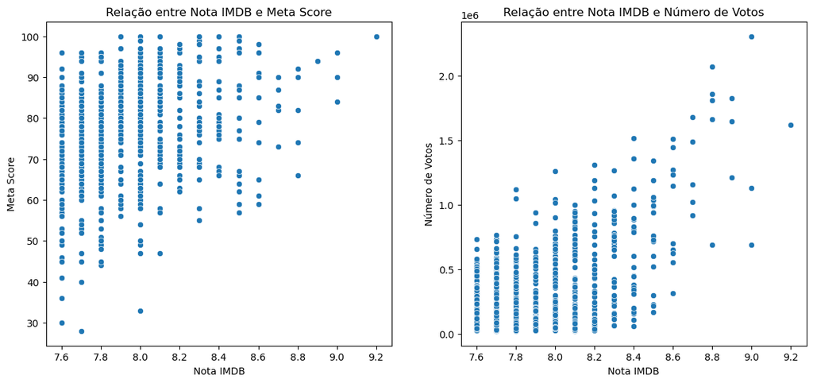

```python
fig, axes = plt.subplots(1, 2, figsize=(14, 6))

sns.scatterplot(x='IMDB_Rating', y='Meta_score', data=df, ax=axes[0])
axes[0].set_title('Relação entre Nota IMDB e Meta Score')
axes[0].set_xlabel('Nota IMDB')
axes[0].set_ylabel('Meta Score')

sns.scatterplot(x='IMDB_Rating', y='No_of_Votes', data=df, ax=axes[1])
axes[1].set_title('Relação entre Nota IMDB e Número de Votos')
axes[1].set_xlabel('Nota IMDB')
axes[1].set_ylabel('Número de Votos')
```

Com base na matriz de correlação e os gráficos de dispersão, percebe-se que a nota IMDB e o numero de votos possuem uma correlação positiva moderada (0,54), que indica que notas mais altas de IMDB tendem a receber mais votos. Isso é confirmado ao observar que o gráfico a direita em que à medida que a nota aumenta os pontos se espalha para cima, sugerindo também que provavelmente esses filmes são mais populares.

Por fim, observa-se que a correlação entre o meta score e o número de votos é praticamente nula, o que indica que o número de votos que um filme recebe não tem relação com a nota que os críticos dão a ele.

#### Análise de Desempenho e Popularidade por Gênero

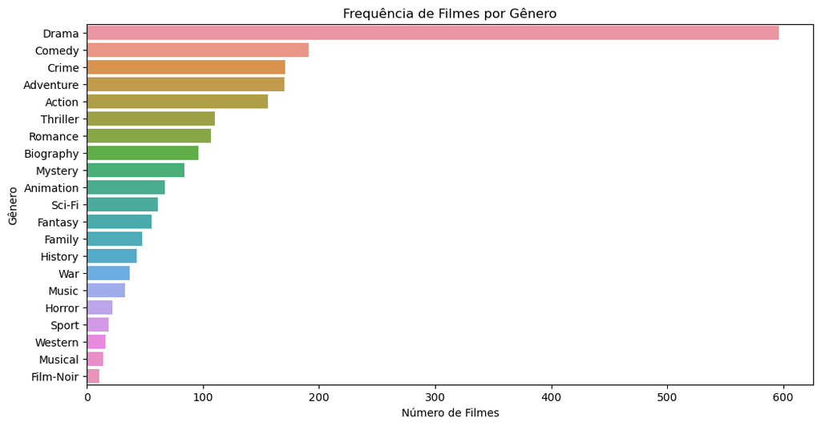

```python
frequencia_generos = generos_dummies.sum().sort_values(ascending=False)

plt.figure(figsize=(12, 6))
sns.barplot(x=frequencia_generos.values, y=frequencia_generos.index)
plt.title('Frequência de Filmes por Gênero')
plt.xlabel('Número de Filmes')
plt.ylabel('Gênero')
plt.show()
```

#### Análise de Rentabilidade dos Gêneros

```python
df_analise = df.join(generos_dummies)
pd.options.display.float_format = '{:,.0f}'.format
generos_para_analisar = generos_dummies.columns

receita_por_genero = df_analise[generos_para_analisar].multiply(df_analise['Gross'], axis=0).sum()
contagem_por_genero = df_analise[generos_para_analisar].sum()

receita_media_por_genero = (receita_por_genero / contagem_por_genero).sort_values(ascending=False)
```

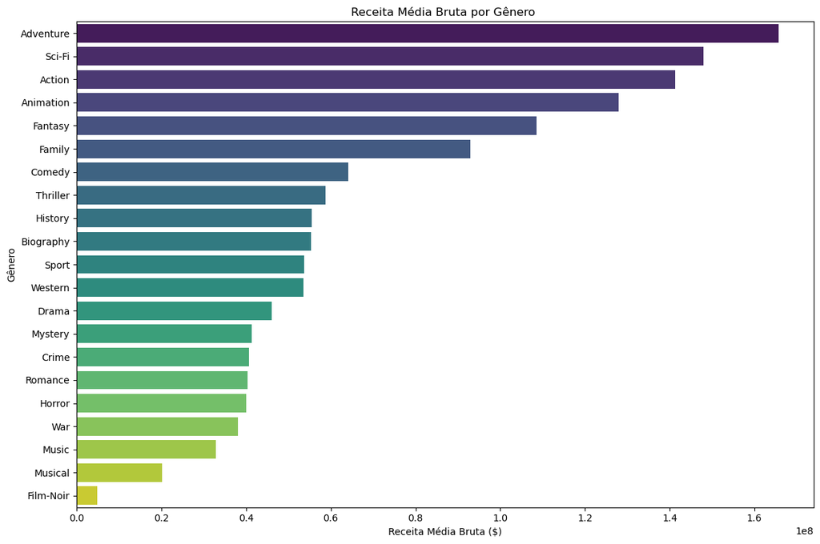

```python
plt.figure(figsize=(12, 8))
sns.barplot(x=receita_media_por_genero.values, y=receita_media_por_genero.index, palette='viridis')
plt.title('Receita Média Bruta por Gênero ')
plt.xlabel('Receita Média Bruta ($)')
plt.ylabel('Gênero')
plt.tight_layout()
plt.show()
```

```python
receita_media_por_genero.head(5)
```

```
Adventure   165,731,279
Sci-Fi      148,026,397
Action      141,239,283
Animation   127,967,528
Fantasy     108,616,842
dtype: float64
```

A análise da receita média mostra que o gênero mais rentável é Aventura com R$165 milhões. Em seguida, temos os gêneros de Sci-Fi, Ação, Animação e Fantasia como os cinco gêneros mais rentáveis. Nesse viés, infere-se que os gêneros voltados a entretenimento de massa são os que geram as maiores receitas.

O gênero drama apesar de ser o mais frequente ocupa uma posição intermediária em termos de receita com uma média inferior. Desse modo, a análise de rentabilidade expõe que popularidade não garante a rentabilidade do gênero.

#### Análise de Desempenho e Popularidade dos Diretores

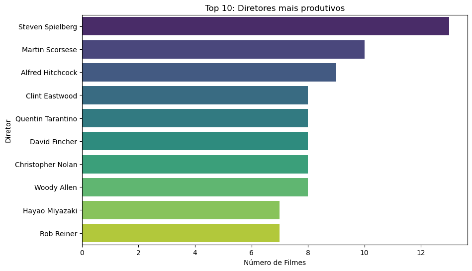

```python
top_10_diretores = df['Director'].value_counts().head(10)

plt.figure(figsize=(10, 6))
sns.barplot(x=top_10_diretores.values, y=top_10_diretores.index, palette='viridis')
plt.title(' Top 10: Diretores mais produtivos ')
plt.xlabel('Número de Filmes')
plt.ylabel('Diretor')
plt.show()
```

O gráfico de barras nos mostra que Steven Spielberg é o diretor mais produtivo com cerca de 13 filmes. Ele é seguido por Martin Scorsese e Alfred Hitchcock, que também se destacam com 10 e 9 obras, respectivamente.

```python
receita_media_por_diretor = df.groupby('Director')['Gross'].mean().sort_values(ascending=False)
top10_receita = receita_media_por_diretor.head(10)
```

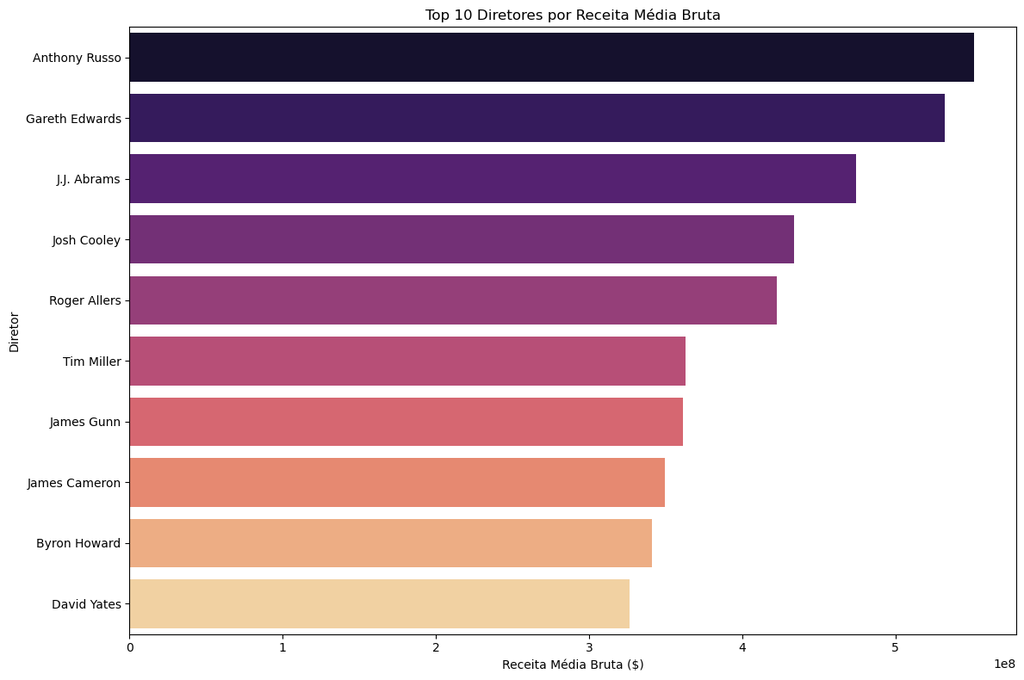

```python
plt.figure(figsize=(12, 8))
sns.barplot(x=top10_receita.values, y=top_10_diretores_receita.index, palette='magma')
plt.title('Top 10 Diretores por Receita Média Bruta')
plt.xlabel('Receita Média Bruta ($)')
plt.ylabel('Diretor')
plt.tight_layout()
plt.savefig('top_10_diretores_receita_media.png')
```

```python
top_10_diretores_receita
```

```
Director
Anthony Russo    551,259,851
Gareth Edwards   532,177,324
J.J. Abrams      474,390,302
Josh Cooley      434,038,008
Roger Allers     422,783,777
Tim Miller       363,070,709
James Gunn       361,494,850
James Cameron    349,647,320
Byron Howard     341,268,248
David Yates      326,317,907
Name: Gross, dtype: float64
```

```
Correlação entre o número de filmes e a receita média: 0.11
```

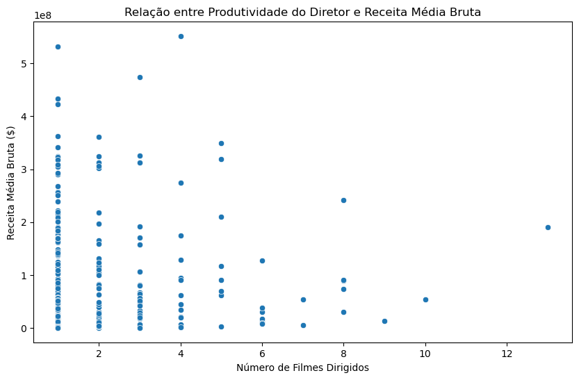

```python
analise_diretores = df.groupby('Director').agg(
    numero_de_filmes=('Series_Title', 'count'),
    receita_media=('Gross', 'mean')
).reset_index()


correlacao_produtividade_receita = analise_diretores['numero_de_filmes'].corr(analise_diretores['receita_media'])
print(f"Correlação entre o número de filmes e a receita média: {correlacao_prolificidade_receita:.2f}")


plt.figure(figsize=(10, 6))
sns.scatterplot(x='numero_de_filmes', y='receita_media', data=analise_diretores)
plt.title('Relação entre Produtividade do Diretor e Receita Média Bruta')
plt.xlabel('Número de Filmes Dirigidos')
plt.ylabel('Receita Média Bruta ($)')
plt.savefig('correlacao_diretor_produtividade.png')
plt.show()
```

```python
analise_diretores_por_filmes = analise_diretores.sort_values(by='numero_de_filmes', ascending=False)
print("\nTop 10 Diretores ordenados por Número de Filmes):")
analise_diretores_por_filmes.head(10)
```

[output not shown]

|  | Director | numero_de_filmes | receita_media |
| --- | --- | --- | --- |
| 408 | Steven Spielberg | 13 | 190,625,628 |
| 275 | Martin Scorsese | 10 | 53,831,920 |
| 17 | Alfred Hitchcock | 9 | 13,234,378 |
| 341 | Quentin Tarantino | 8 | 90,879,290 |
| 73 | Clint Eastwood | 8 | 74,086,580 |
| 86 | David Fincher | 8 | 89,164,310 |
| 72 | Christopher Nolan | 8 | 242,181,763 |
| 462 | Woody Allen | 8 | 30,696,910 |
| 357 | Rob Reiner | 7 | 54,360,978 |
| 158 | Hayao Miyazaki | 7 | 5,577,654 |

A análise dos gráficos e tabelas expõem que a produtividade de um diretor, medida pelo número de filmes, não tem uma correlação direta com sua rentabilidade, medida pela receita média bruta.

Observa-se que a lista dos diretores mais produtivos, como Steven Spielberg e Martin Scorsese, é diferente da lista dos mais rentáveis, que é liderada por Anthony Russo e Gareth Edwards.

O gráfico de dispersão também confirma visualmente essa falta de correlação, mostrando que os diretores com o maior número de filmes não são necessariamente os que alcançam as maiores receitas médias.

Os dados da tabela reforçam essa conclusão, evidenciando que diretores com menos filmes, como Christopher Nolan, podem ter uma receita média superior à de diretores mais produtivos, como Alfred Hitchcock.

```python
df_atores = pd.melt(df, id_vars=['Series_Title', 'Gross'], value_vars=['Star1', 'Star2', 'Star3', 'Star4'], var_name='Tipo_de_Ator', value_name='Nome_do_Ator')
df_atores.drop_duplicates(inplace=True)
receita_media_por_ator = df_atores.groupby('Nome_do_Ator')['Gross'].mean().sort_values(ascending=False)
top_10_atores_receita = receita_media_por_ator.head(10)
```

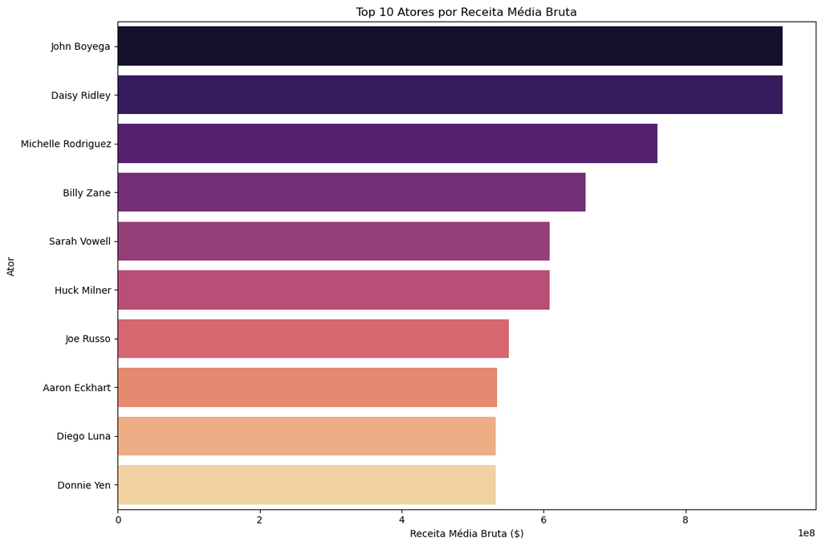

```python
plt.figure(figsize=(12, 8))
sns.barplot(x=top_10_atores_receita.values, y=top_10_atores_receita.index, palette='magma')
plt.title('Top 10 Atores por Receita Média Bruta')
plt.xlabel('Receita Média Bruta ($)')
plt.ylabel('Ator')
plt.tight_layout()
plt.savefig('top_10_atores_receita_media.png')
```

O gráfico "Top 10 Atores por Receita Média Bruta" mostra os atores cujos filmes tiveram a maior receita média. A lista é dominada por atores como John Boyega e Daisy Ridley. É interessante notar que nenhum deles aparece na lista de atores mais frequentes. Isso pode indicar que eles participaram de blockbusters de grande sucesso, como grandes franquias, onde poucos filmes foram suficientes para gerar um retorno financeiro altíssimo.

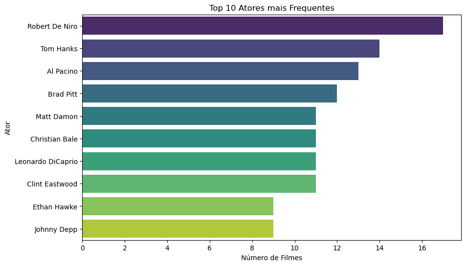

```python
frequencia_total_atores = df_atores['Nome_do_Ator'].value_counts()
top_10_atores_total = frequencia_total_atores.head(10)
plt.figure(figsize=(10, 6))
sns.barplot(x=top_10_atores_total.values, y=top_10_atores_total.index, palette='viridis')
plt.title('Top 10 Atores mais Frequentes')
plt.xlabel('Número de Filmes')
plt.ylabel('Ator')
plt.show()
```

O gráfico "Top 10 Atores mais Frequentes", revela os atores que participaram do maior número de filmes. Robert De Niro lidera a lista com 17 filmes, seguido de perto por Tom Hanks e Al Pacino. A grande quantidade de filmes em que esses atores atuaram sugere que eles são ativos na indústria cinematográfica, mas isso não significa necessariamente que seus filmes foram os mais lucrativos.

```python
analise_atores = df_atores.groupby('Nome_do_Ator').agg(
    numero_de_filmes=('Series_Title', 'count'),
    receita_media=('Gross', 'mean')
).reset_index()

correlacao_atores_receita = analise_atores['numero_de_filmes'].corr(analise_atores['receita_media'])
print(f"Correlação entre o número de filmes e a receita média dos atores: {correlacao_atores_receita:.2f}")


analise_atores_por_filmes = analise_atores.sort_values(by='numero_de_filmes', ascending=False)
print("\nTop 10 Atores ordenados por Número de Filmes (Decrescente):")
analise_atores_por_filmes.head(10)
```

```
Correlação entre o número de filmes e a receita média dos atores: 0.17

Top 10 Atores ordenados por Número de Filmes (Decrescente):
```

|  | Nome_do_Ator | numero_de_filmes | receita_media |
| --- | --- | --- | --- |
| 1801 | Robert De Niro | 17 | 58,921,542 |
| 2103 | Tom Hanks | 14 | 207,397,499 |
| 28 | Al Pacino | 13 | 49,324,030 |
| 249 | Brad Pitt | 12 | 87,519,386 |
| 1441 | Matt Damon | 11 | 157,140,145 |
| 1284 | Leonardo DiCaprio | 11 | 186,299,764 |
| 368 | Christian Bale | 11 | 146,949,035 |
| 398 | Clint Eastwood | 11 | 51,721,819 |
| 1086 | Johnny Depp | 9 | 59,459,246 |
| 617 | Ethan Hawke | 9 | 28,524,884 |

Por fim, a tabela detalhada oferece uma visão completa, combinando a quantidade de filmes de cada ator com a receita média gerada. Fica claro que a frequência não se traduz diretamente em sucesso financeiro visto que, Tom Hanks, com 14 filmes, gerou uma receita média de R$ 207 milhões, enquanto Robert De Niro, com 17 filmes, obteve uma média de apenas R$ 58 milhões. Isso mostra que Tom Hanks tem um impacto financeiro por filme muito maior, mesmo tendo atuado em menos produções que Robert De Niro.